# Data Visualisation Using R — Week-3 Workshop

### Q1. Load the R-package `tidyverse`, which should load the `ggplot2` package. Also, load the `ggthemes` and the `RColorBrewer` packages to access several professional in-built themes and many useful colour palettes, respectively.

### Q2. Create the following plot using the `iris` dataset. (Hint: use `theme_bw()` and remove panel gridlines from the plot.)

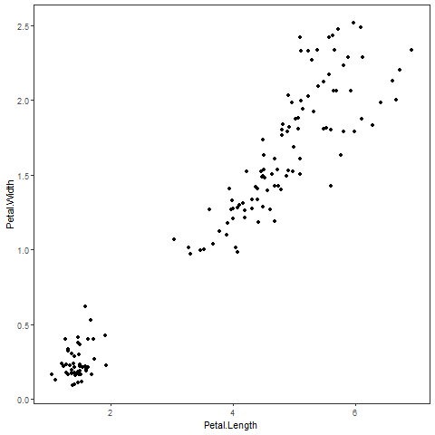

### Q3. Generate the following plot displaying all the major **text elements** in a given plot. (Hint: Use `color = "#2A4DFA"` and play around with the `size` argument to get an appropriate display).

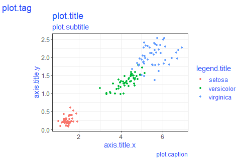

### Q4. Use `mpg` dataset to display the `strip.text` elements in both x and y facets. Hint: Use `drv` and `class` (only consider `suv` and `compact` classes) variables for faceting, but you need to relabel the levels of these two factors.)

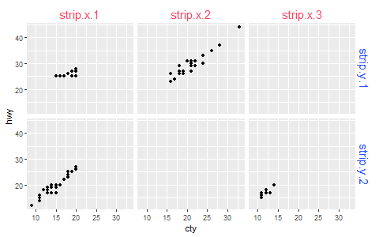

### Q5. Modify strip text elements to create the following visualisation using the `iris` dataset.

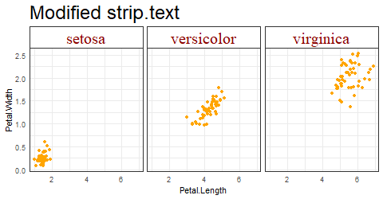

### Q6. Use `iris` dataset to produce the following figure:

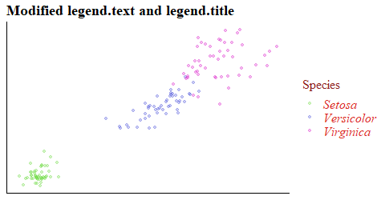

### Q7. Modify the above figure to improve the legend guide – produce the following figure:

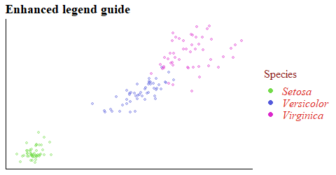

### Q8. Modify the above figure to place the legend on top of the plot – construct the following plot.

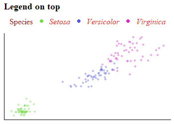

### Q9. Modify the above figure to place the legend inside the plot – construct the following plot.

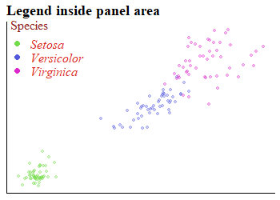

### Q10. Create the customised theme used in the following figure. Also, add the scatter plot and the line of best fit based on the `iris` dataset.

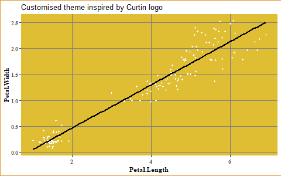

### Q11. Use the Wall street journal theme from the `ggthemes` package to produce the following plot.

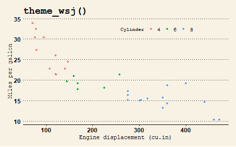

### Q12. Use the FiveThirtyEight theme from the `ggthemes` package to produce the following plot.

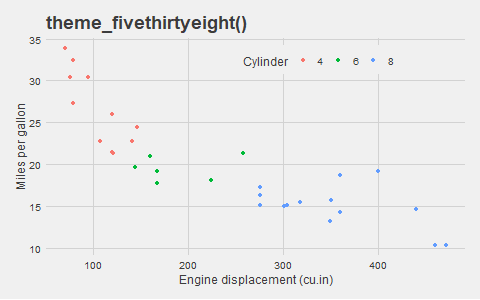

### Q13. Use the Economist journal theme from the `ggthemes` package to produce the following plot.

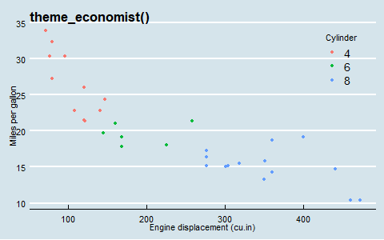

### Q14. Create the following plot using the `diamonds` dataset.

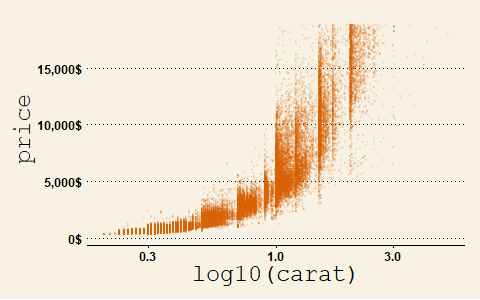

### Q15. Use the `scale_color_brewer()` to produce the plot below.

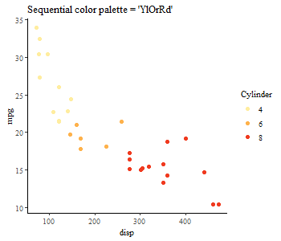

### Q16. Use the `scale_color_manual()` to produce the plot below.

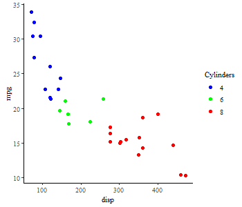